# Fraudlent Tranasaction Prediction

## Data Dictionary

1.step - maps a unit of time in the real world. In this case 1 step is 1 hour of time. Total steps 744 (30 days simulation).

2.type - CASH-IN, CASH-OUT, DEBIT, PAYMENT and TRANSFER.

3.amount - amount of the transaction in local currency.

4.nameOrig - customer who started the transaction

5.oldbalanceOrg - initial balance before the transaction

6.newbalanceOrig - new balance after the transaction

7.nameDest - customer who is the recipient of the transaction

8.oldbalanceDest - initial balance recipient before the transaction. Note that there is not information for customers that start with M (Merchants).

9.newbalanceDest - new balance recipient after the transaction. Note that there is not information for customers that start with M (Merchants).

10.isFraud - This is the transactions made by the fraudulent agents inside the simulation. In this specific dataset the fraudulent behavior of the agents aims to profit by taking control or customers accounts and try to empty the funds by transferring to another account and then cashing out of the system.

11.isFlaggedFraud - The business model aims to control massive transfers from one account to another and flags illegal attempts. An illegal attempt in this dataset is an attempt to transfer more than 200.000 in a single transaction.

## Candidate Expectations

Your task is to execute the process for proactive detection of fraud while answering following questions.

1. Data cleaning including missing values, outliers and multi-collinearity.
2. Describe your fraud detection model in elaboration.
3. How did you select variables to be included in the model?
4. Demonstrate the performance of the model by using best set of tools.
5. What are the key factors that predict fraudulent customer?
6. Do these factors make sense? If yes, How? If not, How not?
7. What kind of prevention should be adopted while company update its infrastructure?
8. Assuming these actions have been implemented, how would you determine if they work?

## Read the data

```python
# import libraries
import pandas as pd
import numpy as np
import matplotlib.pyplot as plt
import seaborn as sns
```

```python
df = pd.read_csv('D:\\Internshala Insaid task\\Fraud.csv')
df
```

|  | step | type | amount | nameOrig | oldbalanceOrg | newbalanceOrig | nameDest | oldbalanceDest | newbalanceDest | isFraud | isFlaggedFraud |
| --- | --- | --- | --- | --- | --- | --- | --- | --- | --- | --- | --- |
| 0 | 1 | PAYMENT | 9839.64 | C1231006815 | 170136.00 | 160296.36 | M1979787155 | 0.00 | 0.00 | 0 | 0 |
| 1 | 1 | PAYMENT | 1864.28 | C1666544295 | 21249.00 | 19384.72 | M2044282225 | 0.00 | 0.00 | 0 | 0 |
| 2 | 1 | TRANSFER | 181.00 | C1305486145 | 181.00 | 0.00 | C553264065 | 0.00 | 0.00 | 1 | 0 |
| 3 | 1 | CASH_OUT | 181.00 | C840083671 | 181.00 | 0.00 | C38997010 | 21182.00 | 0.00 | 1 | 0 |
| 4 | 1 | PAYMENT | 11668.14 | C2048537720 | 41554.00 | 29885.86 | M1230701703 | 0.00 | 0.00 | 0 | 0 |
| ... | ... | ... | ... | ... | ... | ... | ... | ... | ... | ... | ... |
| 6362615 | 743 | CASH_OUT | 339682.13 | C786484425 | 339682.13 | 0.00 | C776919290 | 0.00 | 339682.13 | 1 | 0 |
| 6362616 | 743 | TRANSFER | 6311409.28 | C1529008245 | 6311409.28 | 0.00 | C1881841831 | 0.00 | 0.00 | 1 | 0 |
| 6362617 | 743 | CASH_OUT | 6311409.28 | C1162922333 | 6311409.28 | 0.00 | C1365125890 | 68488.84 | 6379898.11 | 1 | 0 |
| 6362618 | 743 | TRANSFER | 850002.52 | C1685995037 | 850002.52 | 0.00 | C2080388513 | 0.00 | 0.00 | 1 | 0 |
| 6362619 | 743 | CASH_OUT | 850002.52 | C1280323807 | 850002.52 | 0.00 | C873221189 | 6510099.11 | 7360101.63 | 1 | 0 |

6362620 rows × 11 columns

```python
# shape of data
df.shape
```

```
(6362620, 11)
```

```python
# print data type
df.dtypes
```

```
step                int64
type               object
amount            float64
nameOrig           object
oldbalanceOrg     float64
newbalanceOrig    float64
nameDest           object
oldbalanceDest    float64
newbalanceDest    float64
isFraud             int64
isFlaggedFraud      int64
dtype: object
```

From above data types the isFraud variable is integer. Since this is the class variable ,we convert it to object type.

### Convert isFraud column type to object

```python
df['isFraud']= df['isFraud'].astype('object')
df.dtypes
```

```
step                int64
type               object
amount            float64
nameOrig           object
oldbalanceOrg     float64
newbalanceOrig    float64
nameDest           object
oldbalanceDest    float64
newbalanceDest    float64
isFraud            object
isFlaggedFraud      int64
dtype: object
```

```python
df
```

|  | step | type | amount | nameOrig | oldbalanceOrg | newbalanceOrig | nameDest | oldbalanceDest | newbalanceDest | isFraud | isFlaggedFraud |
| --- | --- | --- | --- | --- | --- | --- | --- | --- | --- | --- | --- |
| 0 | 1 | PAYMENT | 9839.64 | C1231006815 | 170136.00 | 160296.36 | M1979787155 | 0.00 | 0.00 | 0 | 0 |
| 1 | 1 | PAYMENT | 1864.28 | C1666544295 | 21249.00 | 19384.72 | M2044282225 | 0.00 | 0.00 | 0 | 0 |
| 2 | 1 | TRANSFER | 181.00 | C1305486145 | 181.00 | 0.00 | C553264065 | 0.00 | 0.00 | 1 | 0 |
| 3 | 1 | CASH_OUT | 181.00 | C840083671 | 181.00 | 0.00 | C38997010 | 21182.00 | 0.00 | 1 | 0 |
| 4 | 1 | PAYMENT | 11668.14 | C2048537720 | 41554.00 | 29885.86 | M1230701703 | 0.00 | 0.00 | 0 | 0 |
| ... | ... | ... | ... | ... | ... | ... | ... | ... | ... | ... | ... |
| 6362615 | 743 | CASH_OUT | 339682.13 | C786484425 | 339682.13 | 0.00 | C776919290 | 0.00 | 339682.13 | 1 | 0 |
| 6362616 | 743 | TRANSFER | 6311409.28 | C1529008245 | 6311409.28 | 0.00 | C1881841831 | 0.00 | 0.00 | 1 | 0 |
| 6362617 | 743 | CASH_OUT | 6311409.28 | C1162922333 | 6311409.28 | 0.00 | C1365125890 | 68488.84 | 6379898.11 | 1 | 0 |
| 6362618 | 743 | TRANSFER | 850002.52 | C1685995037 | 850002.52 | 0.00 | C2080388513 | 0.00 | 0.00 | 1 | 0 |
| 6362619 | 743 | CASH_OUT | 850002.52 | C1280323807 | 850002.52 | 0.00 | C873221189 | 6510099.11 | 7360101.63 | 1 | 0 |

6362620 rows × 11 columns

```python
#check null values
df.isnull().sum()
```

```
step              0
type              0
amount            0
nameOrig          0
oldbalanceOrg     0
newbalanceOrig    0
nameDest          0
oldbalanceDest    0
newbalanceDest    0
isFraud           0
isFlaggedFraud    0
dtype: int64
```

Since we have no missing values in the data

```python
# Summary sttistics of data
df.describe()
```

|  | step | amount | oldbalanceOrg | newbalanceOrig | oldbalanceDest | newbalanceDest | isFlaggedFraud |
| --- | --- | --- | --- | --- | --- | --- | --- |
| count | 6.362620e+06 | 6.362620e+06 | 6.362620e+06 | 6.362620e+06 | 6.362620e+06 | 6.362620e+06 | 6.362620e+06 |
| mean | 2.433972e+02 | 1.798619e+05 | 8.338831e+05 | 8.551137e+05 | 1.100702e+06 | 1.224996e+06 | 2.514687e-06 |
| std | 1.423320e+02 | 6.038582e+05 | 2.888243e+06 | 2.924049e+06 | 3.399180e+06 | 3.674129e+06 | 1.585775e-03 |
| min | 1.000000e+00 | 0.000000e+00 | 0.000000e+00 | 0.000000e+00 | 0.000000e+00 | 0.000000e+00 | 0.000000e+00 |
| 25% | 1.560000e+02 | 1.338957e+04 | 0.000000e+00 | 0.000000e+00 | 0.000000e+00 | 0.000000e+00 | 0.000000e+00 |
| 50% | 2.390000e+02 | 7.487194e+04 | 1.420800e+04 | 0.000000e+00 | 1.327057e+05 | 2.146614e+05 | 0.000000e+00 |
| 75% | 3.350000e+02 | 2.087215e+05 | 1.073152e+05 | 1.442584e+05 | 9.430367e+05 | 1.111909e+06 | 0.000000e+00 |
| max | 7.430000e+02 | 9.244552e+07 | 5.958504e+07 | 4.958504e+07 | 3.560159e+08 | 3.561793e+08 | 1.000000e+00 |

## Exploratory Analysis

```python
Fraud=df.loc[df['isFraud']==1]
print(Fraud)
```

```
         step      type      amount     nameOrig  oldbalanceOrg  \
2           1  TRANSFER      181.00  C1305486145         181.00
3           1  CASH_OUT      181.00   C840083671         181.00
251         1  TRANSFER     2806.00  C1420196421        2806.00
252         1  CASH_OUT     2806.00  C2101527076        2806.00
680         1  TRANSFER    20128.00   C137533655       20128.00
...       ...       ...         ...          ...            ...
6362615   743  CASH_OUT   339682.13   C786484425      339682.13
6362616   743  TRANSFER  6311409.28  C1529008245     6311409.28
6362617   743  CASH_OUT  6311409.28  C1162922333     6311409.28
6362618   743  TRANSFER   850002.52  C1685995037      850002.52
6362619   743  CASH_OUT   850002.52  C1280323807      850002.52

         newbalanceOrig     nameDest  oldbalanceDest  newbalanceDest isFraud  \
2                   0.0   C553264065            0.00            0.00       1
```

[output cut: 25 more lines]

```python
Non_Fraud=df.loc[df['isFraud']==0]
print(Non_Fraud)
```

```
         step      type     amount     nameOrig  oldbalanceOrg  \
0           1   PAYMENT    9839.64  C1231006815       170136.0
1           1   PAYMENT    1864.28  C1666544295        21249.0
4           1   PAYMENT   11668.14  C2048537720        41554.0
5           1   PAYMENT    7817.71    C90045638        53860.0
6           1   PAYMENT    7107.77   C154988899       183195.0
...       ...       ...        ...          ...            ...
6362319   718   PAYMENT    8634.29   C642813806       518802.0
6362320   718  CASH_OUT  159188.22   C691808084         3859.0
6362321   718  CASH_OUT  186273.84   C102120699       168046.0
6362322   718  TRANSFER   82096.45   C614459560        13492.0
6362323   718     DEBIT    1864.24    C49652609        20426.0

         newbalanceOrig     nameDest  oldbalanceDest  newbalanceDest isFraud  \
0             160296.36  M1979787155            0.00            0.00       0
```

[output cut: 25 more lines]

```python
df['isFraud'].value_counts()
# 0- Non-Fraud
#1- Fraud
```

```
0    6354407
1       8213
Name: isFraud, dtype: int64
```

```python
# normalise can be set to true to print proportion instead of number
df['isFraud'].value_counts(normalize=True)
```

```
0    0.998709
1    0.001291
Name: isFraud, dtype: float64
```

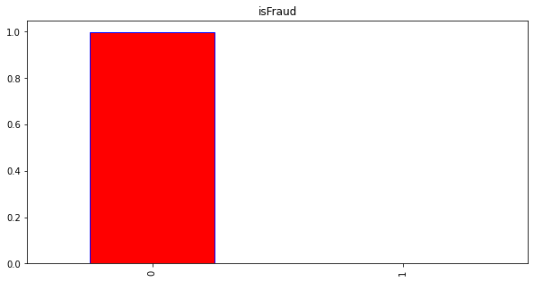

```python
plt.figure(figsize=(10,5))
df['isFraud'].value_counts(normalize=True).plot.bar(title='isFraud',color='r',edgecolor='b')
```

From above plot , we see that about 0.13% of the data is fraud.Hence there is class imbalance in data .

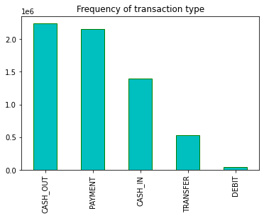

```python
df['type'].value_counts().plot.bar(title='Frequency of transaction type',color='c',edgecolor='g')
```

From above graph, the most frequntly used transaction type is cash_out and payment.

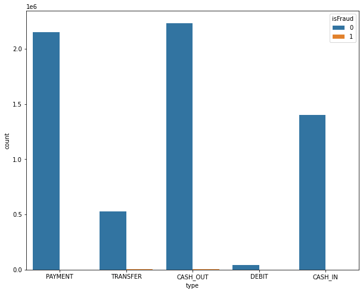

```python
import seaborn as sns
import matplotlib.pyplot as plt
plt.figure(figsize=(10, 8))
sns.countplot(df['type'],data= df,hue='isFraud')
```

Hence , most fraudlent are from type cash_out and transfer.

## To Find Outliers in the data

```python
ColType = (df.dtypes).reset_index()
print (ColType)
```

```
             index        0
0             step    int64
1             type   object
2           amount  float64
3         nameOrig   object
4    oldbalanceOrg  float64
5   newbalanceOrig  float64
6         nameDest   object
7   oldbalanceDest  float64
8   newbalanceDest  float64
9          isFraud   object
10  isFlaggedFraud    int64
```

```python
FileNameDesc = pd.DataFrame(columns=['ColumnName', 'MissingCount','MissingPercentage','UniqueValues'])

for col in list(df.columns.values):
    sum_missing = df[col].isnull().sum()
    percent_missing = (sum_missing/len(df)) *100
    uniq_count =(df.groupby ([col])[col].count()).count()
    FileNameDesc = FileNameDesc.append ({'ColumnName': col,'MissingCount':sum_missing,'MissingPercentage': percent_missing,
                                        'UniqueValues': uniq_count} ,ignore_index=True  )
```

```python
FileNameDesc
```

|  | ColumnName | MissingCount | MissingPercentage | UniqueValues |
| --- | --- | --- | --- | --- |
| 0 | step | 0 | 0.0 | 743 |
| 1 | type | 0 | 0.0 | 5 |
| 2 | amount | 0 | 0.0 | 5316900 |
| 3 | nameOrig | 0 | 0.0 | 6353307 |
| 4 | oldbalanceOrg | 0 | 0.0 | 1845844 |
| 5 | newbalanceOrig | 0 | 0.0 | 2682586 |
| 6 | nameDest | 0 | 0.0 | 2722362 |
| 7 | oldbalanceDest | 0 | 0.0 | 3614697 |
| 8 | newbalanceDest | 0 | 0.0 | 3555499 |
| 9 | isFraud | 0 | 0.0 | 2 |
| 10 | isFlaggedFraud | 0 | 0.0 | 2 |

```python
#Adjust the Display settings
pd.set_option('display.width',2000)
FileNameDesc = FileNameDesc.merge(ColType, left_on ='ColumnName',right_on ='index',how ='inner')
print (FileNameDesc)
```

```
        ColumnName MissingCount  MissingPercentage UniqueValues           index        0
0             step            0                0.0          743            step    int64
1             type            0                0.0            5            type   object
2           amount            0                0.0      5316900          amount  float64
3         nameOrig            0                0.0      6353307        nameOrig   object
4    oldbalanceOrg            0                0.0      1845844   oldbalanceOrg  float64
5   newbalanceOrig            0                0.0      2682586  newbalanceOrig  float64
6         nameDest            0                0.0      2722362        nameDest   object
7   oldbalanceDest            0                0.0      3614697  oldbalanceDest  float64
8   newbalanceDest            0                0.0      3555499  newbalanceDest  float64
9          isFraud            0                0.0            2         isFraud   object
10  isFlaggedFraud            0                0.0            2  isFlaggedFraud    int64
```

```python
del FileNameDesc['index']
```

```python
FileNameDesc = FileNameDesc.rename(index=str, columns = {0:"column_type"})
print (FileNameDesc)
```

```
        ColumnName MissingCount  MissingPercentage UniqueValues column_type
0             step            0                0.0          743       int64
1             type            0                0.0            5      object
2           amount            0                0.0      5316900     float64
3         nameOrig            0                0.0      6353307      object
4    oldbalanceOrg            0                0.0      1845844     float64
5   newbalanceOrig            0                0.0      2682586     float64
6         nameDest            0                0.0      2722362      object
7   oldbalanceDest            0                0.0      3614697     float64
8   newbalanceDest            0                0.0      3555499     float64
9          isFraud            0                0.0            2      object
10  isFlaggedFraud            0                0.0            2       int64
```

## Function to Remove outliers

```python
def remove_outlier(df_in, col_name):
    q1 = df_in[col_name].quantile(0.25)
    q3 = df_in[col_name].quantile(0.75)
    iqr = q3-q1
    fence_low = q1 - 1.5*iqr
    fence_high = q3 + 1.5*iqr
    df_out = df_in.loc[(df_in[col_name]> fence_low) & (df_in[col_name] < fence_high)]
    return df_out
```

```python
#Get int or Float columns to pass to Function to Remove outliers
df_col=FileNameDesc[(FileNameDesc.column_type=='int64') | (FileNameDesc.column_type =='float64')]
print (df_col)
```

```
        ColumnName MissingCount  MissingPercentage UniqueValues column_type
0             step            0                0.0          743       int64
2           amount            0                0.0      5316900     float64
4    oldbalanceOrg            0                0.0      1845844     float64
5   newbalanceOrig            0                0.0      2682586     float64
7   oldbalanceDest            0                0.0      3614697     float64
8   newbalanceDest            0                0.0      3555499     float64
10  isFlaggedFraud            0                0.0            2       int64
```

```python
for col_na in df_col['ColumnName']:
        remove_outlier(df, col_na)
```

```python
df
```

|  | step | type | amount | nameOrig | oldbalanceOrg | newbalanceOrig | nameDest | oldbalanceDest | newbalanceDest | isFraud | isFlaggedFraud |
| --- | --- | --- | --- | --- | --- | --- | --- | --- | --- | --- | --- |
| 0 | 1 | PAYMENT | 9839.64 | C1231006815 | 170136.00 | 160296.36 | M1979787155 | 0.00 | 0.00 | 0 | 0 |
| 1 | 1 | PAYMENT | 1864.28 | C1666544295 | 21249.00 | 19384.72 | M2044282225 | 0.00 | 0.00 | 0 | 0 |
| 2 | 1 | TRANSFER | 181.00 | C1305486145 | 181.00 | 0.00 | C553264065 | 0.00 | 0.00 | 1 | 0 |
| 3 | 1 | CASH_OUT | 181.00 | C840083671 | 181.00 | 0.00 | C38997010 | 21182.00 | 0.00 | 1 | 0 |
| 4 | 1 | PAYMENT | 11668.14 | C2048537720 | 41554.00 | 29885.86 | M1230701703 | 0.00 | 0.00 | 0 | 0 |
| ... | ... | ... | ... | ... | ... | ... | ... | ... | ... | ... | ... |
| 6362615 | 743 | CASH_OUT | 339682.13 | C786484425 | 339682.13 | 0.00 | C776919290 | 0.00 | 339682.13 | 1 | 0 |
| 6362616 | 743 | TRANSFER | 6311409.28 | C1529008245 | 6311409.28 | 0.00 | C1881841831 | 0.00 | 0.00 | 1 | 0 |
| 6362617 | 743 | CASH_OUT | 6311409.28 | C1162922333 | 6311409.28 | 0.00 | C1365125890 | 68488.84 | 6379898.11 | 1 | 0 |
| 6362618 | 743 | TRANSFER | 850002.52 | C1685995037 | 850002.52 | 0.00 | C2080388513 | 0.00 | 0.00 | 1 | 0 |
| 6362619 | 743 | CASH_OUT | 850002.52 | C1280323807 | 850002.52 | 0.00 | C873221189 | 6510099.11 | 7360101.63 | 1 | 0 |

6362620 rows × 11 columns

```python
# Let nameOrig and nameDest are not needed for clasification ,hence we remove them
df= df.drop(['nameOrig','nameDest'],axis=1)
df
```

|  | step | type | amount | oldbalanceOrg | newbalanceOrig | oldbalanceDest | newbalanceDest | isFraud | isFlaggedFraud |
| --- | --- | --- | --- | --- | --- | --- | --- | --- | --- |
| 0 | 1 | PAYMENT | 9839.64 | 170136.00 | 160296.36 | 0.00 | 0.00 | 0 | 0 |
| 1 | 1 | PAYMENT | 1864.28 | 21249.00 | 19384.72 | 0.00 | 0.00 | 0 | 0 |
| 2 | 1 | TRANSFER | 181.00 | 181.00 | 0.00 | 0.00 | 0.00 | 1 | 0 |
| 3 | 1 | CASH_OUT | 181.00 | 181.00 | 0.00 | 21182.00 | 0.00 | 1 | 0 |
| 4 | 1 | PAYMENT | 11668.14 | 41554.00 | 29885.86 | 0.00 | 0.00 | 0 | 0 |
| ... | ... | ... | ... | ... | ... | ... | ... | ... | ... |
| 6362615 | 743 | CASH_OUT | 339682.13 | 339682.13 | 0.00 | 0.00 | 339682.13 | 1 | 0 |
| 6362616 | 743 | TRANSFER | 6311409.28 | 6311409.28 | 0.00 | 0.00 | 0.00 | 1 | 0 |
| 6362617 | 743 | CASH_OUT | 6311409.28 | 6311409.28 | 0.00 | 68488.84 | 6379898.11 | 1 | 0 |
| 6362618 | 743 | TRANSFER | 850002.52 | 850002.52 | 0.00 | 0.00 | 0.00 | 1 | 0 |
| 6362619 | 743 | CASH_OUT | 850002.52 | 850002.52 | 0.00 | 6510099.11 | 7360101.63 | 1 | 0 |

6362620 rows × 9 columns

```python
df
```

|  | step | type | amount | oldbalanceOrg | newbalanceOrig | oldbalanceDest | newbalanceDest | isFraud | isFlaggedFraud |
| --- | --- | --- | --- | --- | --- | --- | --- | --- | --- |
| 0 | 1 | PAYMENT | 9839.64 | 170136.00 | 160296.36 | 0.00 | 0.00 | 0 | 0 |
| 1 | 1 | PAYMENT | 1864.28 | 21249.00 | 19384.72 | 0.00 | 0.00 | 0 | 0 |
| 2 | 1 | TRANSFER | 181.00 | 181.00 | 0.00 | 0.00 | 0.00 | 1 | 0 |
| 3 | 1 | CASH_OUT | 181.00 | 181.00 | 0.00 | 21182.00 | 0.00 | 1 | 0 |
| 4 | 1 | PAYMENT | 11668.14 | 41554.00 | 29885.86 | 0.00 | 0.00 | 0 | 0 |
| ... | ... | ... | ... | ... | ... | ... | ... | ... | ... |
| 6362615 | 743 | CASH_OUT | 339682.13 | 339682.13 | 0.00 | 0.00 | 339682.13 | 1 | 0 |
| 6362616 | 743 | TRANSFER | 6311409.28 | 6311409.28 | 0.00 | 0.00 | 0.00 | 1 | 0 |
| 6362617 | 743 | CASH_OUT | 6311409.28 | 6311409.28 | 0.00 | 68488.84 | 6379898.11 | 1 | 0 |
| 6362618 | 743 | TRANSFER | 850002.52 | 850002.52 | 0.00 | 0.00 | 0.00 | 1 | 0 |
| 6362619 | 743 | CASH_OUT | 850002.52 | 850002.52 | 0.00 | 6510099.11 | 7360101.63 | 1 | 0 |

6362620 rows × 9 columns

```python
df['type']= df['type'].astype('category')
df.dtypes
```

```
step                 int64
type              category
amount             float64
oldbalanceOrg      float64
newbalanceOrig     float64
oldbalanceDest     float64
newbalanceDest     float64
isFraud             object
isFlaggedFraud       int64
dtype: object
```

```python
from sklearn.preprocessing import LabelEncoder
# creating instance of labelencoder
labelencoder = LabelEncoder()
df['newtype'] = labelencoder.fit_transform(df['type'])
df
```

|  | step | type | amount | oldbalanceOrg | newbalanceOrig | oldbalanceDest | newbalanceDest | isFraud | isFlaggedFraud | newtype |
| --- | --- | --- | --- | --- | --- | --- | --- | --- | --- | --- |
| 0 | 1 | PAYMENT | 9839.64 | 170136.00 | 160296.36 | 0.00 | 0.00 | 0 | 0 | 3 |
| 1 | 1 | PAYMENT | 1864.28 | 21249.00 | 19384.72 | 0.00 | 0.00 | 0 | 0 | 3 |
| 2 | 1 | TRANSFER | 181.00 | 181.00 | 0.00 | 0.00 | 0.00 | 1 | 0 | 4 |
| 3 | 1 | CASH_OUT | 181.00 | 181.00 | 0.00 | 21182.00 | 0.00 | 1 | 0 | 1 |
| 4 | 1 | PAYMENT | 11668.14 | 41554.00 | 29885.86 | 0.00 | 0.00 | 0 | 0 | 3 |
| ... | ... | ... | ... | ... | ... | ... | ... | ... | ... | ... |
| 6362615 | 743 | CASH_OUT | 339682.13 | 339682.13 | 0.00 | 0.00 | 339682.13 | 1 | 0 | 1 |
| 6362616 | 743 | TRANSFER | 6311409.28 | 6311409.28 | 0.00 | 0.00 | 0.00 | 1 | 0 | 4 |
| 6362617 | 743 | CASH_OUT | 6311409.28 | 6311409.28 | 0.00 | 68488.84 | 6379898.11 | 1 | 0 | 1 |
| 6362618 | 743 | TRANSFER | 850002.52 | 850002.52 | 0.00 | 0.00 | 0.00 | 1 | 0 | 4 |
| 6362619 | 743 | CASH_OUT | 850002.52 | 850002.52 | 0.00 | 6510099.11 | 7360101.63 | 1 | 0 | 1 |

6362620 rows × 10 columns

```python
df.drop(['type'],axis=1,inplace=True)
df
```

|  | step | amount | oldbalanceOrg | newbalanceOrig | oldbalanceDest | newbalanceDest | isFraud | isFlaggedFraud | newtype |
| --- | --- | --- | --- | --- | --- | --- | --- | --- | --- |
| 0 | 1 | 9839.64 | 170136.00 | 160296.36 | 0.00 | 0.00 | 0 | 0 | 3 |
| 1 | 1 | 1864.28 | 21249.00 | 19384.72 | 0.00 | 0.00 | 0 | 0 | 3 |
| 2 | 1 | 181.00 | 181.00 | 0.00 | 0.00 | 0.00 | 1 | 0 | 4 |
| 3 | 1 | 181.00 | 181.00 | 0.00 | 21182.00 | 0.00 | 1 | 0 | 1 |
| 4 | 1 | 11668.14 | 41554.00 | 29885.86 | 0.00 | 0.00 | 0 | 0 | 3 |
| ... | ... | ... | ... | ... | ... | ... | ... | ... | ... |
| 6362615 | 743 | 339682.13 | 339682.13 | 0.00 | 0.00 | 339682.13 | 1 | 0 | 1 |
| 6362616 | 743 | 6311409.28 | 6311409.28 | 0.00 | 0.00 | 0.00 | 1 | 0 | 4 |
| 6362617 | 743 | 6311409.28 | 6311409.28 | 0.00 | 68488.84 | 6379898.11 | 1 | 0 | 1 |
| 6362618 | 743 | 850002.52 | 850002.52 | 0.00 | 0.00 | 0.00 | 1 | 0 | 4 |
| 6362619 | 743 | 850002.52 | 850002.52 | 0.00 | 6510099.11 | 7360101.63 | 1 | 0 | 1 |

6362620 rows × 9 columns

## Splitting of data

```python
x=df[['step','amount','oldbalanceOrg','newbalanceOrig','oldbalanceDest','newbalanceDest','isFlaggedFraud','newtype']]
y= df['isFraud']
```

```python
x.shape
```

```
(6362620, 8)
```

```python
y.shape
```

```
(6362620,)
```

```python
from sklearn.preprocessing import StandardScaler
sc= StandardScaler()
x=sc.fit_transform(x)
```

```python
x
```

```
array([[-1.70304158e+00, -2.81559923e-01, -2.29810037e-01, ...,
        -3.33411405e-01, -1.58577857e-03,  9.52399323e-01],
       [-1.70304158e+00, -2.94767262e-01, -2.81359380e-01, ...,
        -3.33411405e-01, -1.58577857e-03,  9.52399323e-01],
       [-1.70304158e+00, -2.97554804e-01, -2.88653782e-01, ...,
        -3.33411405e-01, -1.58577857e-03,  1.69307616e+00],
       ...,
       [ 3.51012348e+00,  1.01539526e+01,  1.89649113e+00, ...,
         1.40302700e+00, -1.58577857e-03, -5.28954357e-01],
       [ 3.51012348e+00,  1.10976490e+00,  5.58104668e-03, ...,
        -3.33411405e-01, -1.58577857e-03,  1.69307616e+00],
       [ 3.51012348e+00,  1.10976490e+00,  5.58104668e-03, ...,
         1.66981230e+00, -1.58577857e-03, -5.28954357e-01]])
```

```python
y=y.astype('int')
y.dtypes
```

```
dtype('int32')
```

```python
# Splitting the dataset into the Training set and Test set
from sklearn.model_selection import train_test_split
X_train, X_test,y_train,y_test = train_test_split(x, y,train_size=0.70, test_size = 0.30, random_state =0)


print(X_train.shape)
print(y_train.shape)
print(X_test.shape)
print(y_test.shape)
```

```
(4453834, 8)
(4453834,)
(1908786, 8)
(1908786,)
```

### Random Forest Classifier

```python
from sklearn.ensemble import RandomForestClassifier
# create random forest classifier
rf_model= RandomForestClassifier(n_estimators = 100,random_state=0)

#training the classifier
rf_model.fit(X_train,y_train)

#Applying trained classifier to test
y_pred = rf_model.predict(X_test)
```

```python
# for train data
#Predict the response for train data
y_pred_t= rf_model.predict(X_train)
```

```python
# creating confusion matrix
from sklearn.metrics import confusion_matrix,classification_report,accuracy_score

cm=confusion_matrix(y_pred,y_test)
print(cm)
print(classification_report(y_pred,y_test))
```

```
[[1906327     510]
 [     40    1909]]
              precision    recall  f1-score   support

           0       1.00      1.00      1.00   1906837
           1       0.79      0.98      0.87      1949

    accuracy                           1.00   1908786
   macro avg       0.89      0.99      0.94   1908786
weighted avg       1.00      1.00      1.00   1908786
```

```python
accuracy= accuracy_score(y_pred,y_test)
print("Accuracy of Random Forest Classifier for test data  is :",accuracy)
```

```
Accuracy of Random Forest Classifier for test data  is : 0.9997118587416295
```

```python
accuracy_train=accuracy_score(y_train,y_pred_t)
print("Accuracy of Random Forest classifier for train data is :",accuracy_train)
```

```
Accuracy of Random Forest classifier for train data is : 0.9999995509486882
```

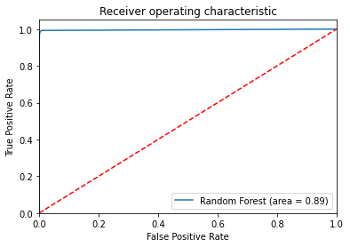

```python
from sklearn.metrics import roc_auc_score
from sklearn.metrics import roc_curve
logit_roc_auc = roc_auc_score(y_test, rf_model.predict(X_test))
fpr, tpr, thresholds = roc_curve(y_test, rf_model.predict_proba(X_test)[:,1])
plt.figure()
plt.plot(fpr, tpr, label='Random Forest (area = %0.2f)' % logit_roc_auc)
plt.plot([0, 1], [0, 1],'r--')
plt.xlim([0.0, 1.0])
plt.ylim([0.0, 1.05])
plt.xlabel('False Positive Rate')
plt.ylabel('True Positive Rate')
plt.title('Receiver operating characteristic')
plt.legend(loc="lower right")
plt.savefig('Log_ROC_RF')
plt.show()
```

## Logistic Regression

```python
from sklearn.linear_model import LogisticRegression
from sklearn import metrics
model = LogisticRegression()
model.fit(X_train,y_train)
predictions = model.predict(X_test)


print("Accuracy of Logistic Regression for test data is :",metrics.accuracy_score(y_test, predictions))
```

```
Accuracy of Logistic Regression for test data is : 0.9992120646316559
```

```python
predictions_train = model.predict(X_train)

print("Accuracy of Logistic Regression for train data is :",metrics.accuracy_score(y_train, predictions_train))
```

```
Accuracy of Logistic Regression for train data is : 0.9992139356787882
```

```python
# implementing the confusion matrix
from sklearn.metrics import confusion_matrix
cm = confusion_matrix(y_test,predictions)
print(cm)
```

```
[[1906259     108]
 [   1396    1023]]
```

From confusion matrix , we see that there is the imbalanced data

```python
# from sklearn.metrics import classification_report
print(classification_report(y_test, predictions))
```

```
              precision    recall  f1-score   support

           0       1.00      1.00      1.00   1906367
           1       0.90      0.42      0.58      2419

    accuracy                           1.00   1908786
   macro avg       0.95      0.71      0.79   1908786
weighted avg       1.00      1.00      1.00   1908786
```

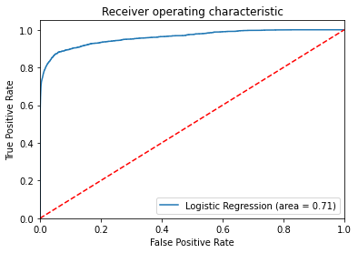

```python
from sklearn.metrics import roc_auc_score
from sklearn.metrics import roc_curve
logit_roc_auc = roc_auc_score(y_test, model.predict(X_test))
fpr, tpr, thresholds = roc_curve(y_test, model.predict_proba(X_test)[:,1])
plt.figure()
plt.plot(fpr, tpr, label='Logistic Regression (area = %0.2f)' % logit_roc_auc)
plt.plot([0, 1], [0, 1],'r--')
plt.xlim([0.0, 1.0])
plt.ylim([0.0, 1.05])
plt.xlabel('False Positive Rate')
plt.ylabel('True Positive Rate')
plt.title('Receiver operating characteristic')
plt.legend(loc="lower right")
plt.savefig('Log_ROC')
plt.show()
```

From roc curve, random forest model have higher accuracy than logistic regrssion.